# Markov-Switching AutoRegressive Regression (MS-ARR)

Forecasting Severe Acute Patient Harm Resulting from Emergency Department Delays

Authors

Affiliation

Mustafa Aslan

Data Lab for Social Good, Cardiff Business School

Harsha Halgamuwe Hewage

Data Lab for Social Good, Cardiff Business School

Prof. Bahman Rostami-Tabar

Data Lab for Social Good, Cardiff Business School

Published

September 23, 2026

[figure not shown]

Winner • Joint 1st SPHERE-PPL Forecasting Contest • NHS Acute Patient Harm (1–5 Day Category)

# Markov-Switching AutoRegressive Regression (MS-ARR) Forecasting Severe Acute Patient Harm Resulting from Emergency Department Delays

Winning Team • Data Lab for Social Good

Prof. Bahman Rostami-Tabar

Professor of Analytics & Decision Sciences

Director, Data Lab for Social Good Research Group  
Cardiff Business School, Cardiff University

Mustafa Aslan

PhD Student

Data Lab for Social Good Research Group  
Cardiff Business School, Cardiff University

Harsha Halgamuwe Hewage

PhD Student

Data Lab for Social Good Research Group  
Cardiff Business School, Cardiff University

23 September 2026

## 1. What Are We Forecasting?

The Target Outcome Variable

- **Target Variable ($y_t$):** Daily **Estimated Avoidable Deaths (EAD)**
  $$\text{EAD}_t = \sum_{i \in \text{Admissions}_t} \Big[ p_i(\text{delay}_i, \mathbf{z}_i) - p_i(0, \mathbf{z}_i) \Big]$$
  - $\mathbf{z}_i$: Baseline patient case-mix vector (age, triage acuity, comorbidities).
  - $\text{delay}_i$: Hours delayed in Emergency Department (ED) awaiting an inpatient hospital bed.
  - $p_i(\cdot)$: 30-day mortality risk model.
- **Forecasting Objective:** Generate daily forecasts over a **10-day horizon** ($h = 1, \dots, 10$ days ahead) using near-real-time operational and patient-flow data.
- **Evaluation Criteria:** **Days 1–5** ($\text{MSE}_{1\text{–}5\text{d}}$) and **Days 6–10** ($\text{MSE}_{6\text{–}10\text{d}}$).

Key Forecasting Constraints & Rules

- **Midday Forecasting Cut-off:** Forecasts for days $D+1$ to $D+10$ can only use information available up to midday on day $D$.
- **Strict 3-Day Reporting Lag:**  
  Because of clinical validation and mortality verification lags, the true target variable $y$ is only known up to **$D-3$**.
  - On Day $D$, the most recent verified observation available is **$y_{D-3}$**.
- **Sliding Evaluation Windows:** 131 sliding 10-day forecast windows evaluated across the hold-out test period (October 2025 – March 2026).

## 2. Model: Markov-Switching AutoRegressive Regression (MS-ARR)

### MS-ARR Formulation

$$y_t \mid (r_t = r) = \beta_{0}^{(r)} + \sum_{i=1}^{p} \beta_{i}^{(r)} \, y_{t-i} + \sum_{m=p+1}^{M} \beta_{m}^{(r)} X_{tm} + \epsilon_t$$

where $\epsilon_t \sim \mathcal{N}\!\left(0, \sigma_r^2\right)$ is $i.i.d.$ Gaussian noise with regime-specific variance $\sigma_r^2$.

- To model regime dynamics, we assume that the latent process $\{r_t\}$ satisfies the first-order Markov property:

$$P(r_t = j \mid r_{1:t-1}) = P(r_t = j \mid r_{t-1}), \qquad j \in \mathcal{R}, \; t \ge 2.$$

- The transition probabilities between states form the transition matrix $\mathbf{P}$:

$$\mathbf{P} =
\begin{pmatrix}
p_{11} & \cdots & p_{1K} \\
\vdots & \ddots & \vdots \\
p_{K1} & \cdots & p_{KK}
\end{pmatrix}.$$

### Notation & Definitions

- $y_t$: Observed number of avoidable deaths at time $t$
- $r_t$: Unobserved (latent) operational regime at time $t$
- $X_{tm}$: Exogenous predictors (cyclical, calendar, operational indicators)
- $\beta_{0}^{(r)}$: Regime-specific baseline intercept
- $\beta_{i}^{(r)}$: Autoregressive coefficients associated with the $i$-th lag in regime $r$
- $\beta_{m}^{(r)}$: Coefficients for exogenous covariates in regime $r$
- $K$: Total number of regimes ($\mathcal{R} = \{1, 2, \ldots, K\}$, here $K = 2$)

### Parameter Estimation & Forecasting Theory

#### Parameter Estimation of MS-ARR

Model parameters are estimated using the **Expectation–Maximization (EM)** algorithm (Baum–Welch algorithm), which iteratively refines the full parameter vector:

$$\theta = \{\beta^{(r)}, \sigma_r^2, \mathbf{P}, \boldsymbol{\pi} \}_{r \in \mathcal{R}}$$

by maximising the marginal log-likelihood of the observed EAD time series $y_{1:T} = (y_1, \ldots, y_T)$.

**NoteEM Algorithm (The Forward-Backward Algorithm - Baum-Welch)**

Let $k$ denote the iteration index. The algorithm iterates between:

$$\begin{aligned}
&\textbf{E-step:} \quad
Q(\theta \mid \theta^{(k)})
=
\mathbb{E}_{\,r_{1:T} \mid y_{1:T},\, \theta^{(k)}}
\left[
\log p(y_{1:T}, r_{1:T} \mid \theta)
\right]
\\[8pt]
&\textbf{M-step:} \quad
\theta^{(k+1)}
=
\arg\max_{\theta}\,
Q(\theta \mid \theta^{(k)})
\\[8pt]
&\textbf{Convergence:} \quad
\theta^{(0)} \;\rightarrow\; \text{E-step} \;\rightarrow\; \text{M-step} \;\rightarrow\; \theta^{(1)} \;\rightarrow\; \cdots \;\rightarrow\; \theta^{(k+1)}
\end{aligned}$$

#### Forecasting with MS-ARR

Let $P(r_T = i \mid \mathcal{O}_{1:T})$ denote the filtered posterior probability of being in regime $i$ at time $T$. The $h$-step-ahead regime probabilities evolve according to:

$$P(r_{T+h} = j \mid \mathcal{O}_{1:T})
=
\sum_{i=1}^{K}
P(r_{T+h-1} = i \mid \mathcal{O}_{1:T}) \, p_{ij},
\qquad h \ge 1.$$

Conditional on regime $r_{T+h} = r$, the $h$-step-ahead forecast is generated from the regime-specific autoregressive equation:

$$\hat{y}_{T+h}^{(r)}
=
\beta_{0}^{(r)}
+
\sum_{i=1}^{p}
\beta_{i}^{(r)} \, y_{T+h-i}
+
\sum_{m=1}^{M}
\beta_{p+m}^{(r)} \, X_{T+h,m}$$

The final point forecast at horizon $h$ is computed as a probability-weighted mixture over all regimes:

$$\hat{y}_{T+h}
=
\sum_{r=1}^{K}
P(r_{T+h} = r \mid y_{1:T}) \, \hat{y}_{T+h}^{(r)}.$$

## 3. Model Results: Regime Dynamics & Switches

### Setup & Shared Data Loading

**Data artifacts loaded:** `ms_arr_model_results.pkl`, `cv_results.pkl`, `probabilistic_forecast_results.pkl`, and operational CSV datasets.

### Regime Switches in EAD History

Below, the historical EAD trajectory is displayed alongside the filtered posterior probability of occupying **Regime 2 (Peak Risk)**. Notice how sudden shifts in avoidable mortality correspond to heightened peak-risk probabilities.

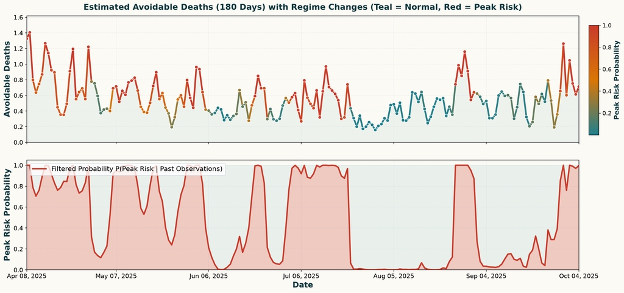

Generated Figure

### Regime Structure: Variance Comparison & Transition Probabilities

#### Residual Error Variances ($\sigma_r^2$)

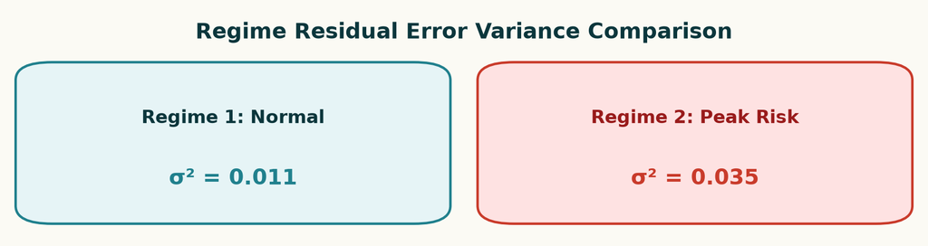

Generated Figure

#### Transition Probability Matrix $\mathbf{P}$

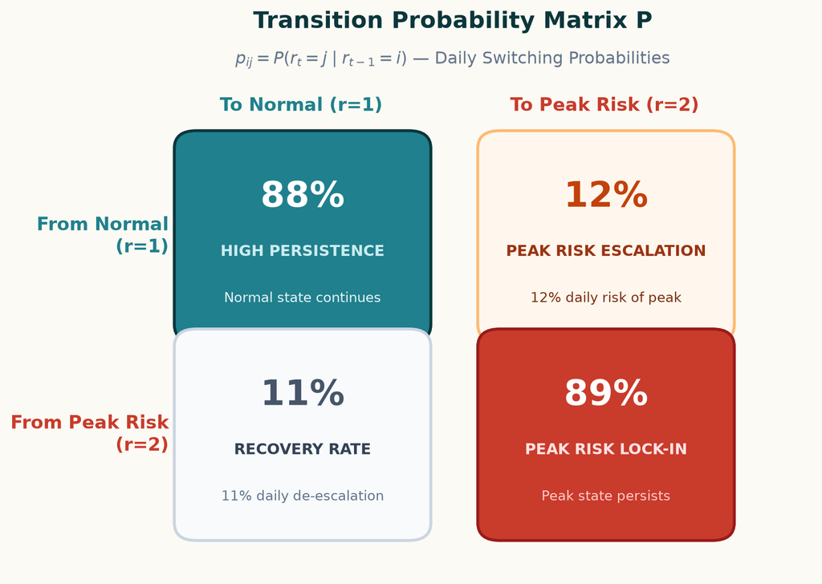

Generated Figure

#### Regime Inertia & Equilibrium Occupancy

[figure not shown]

Generated Figure

## 4. Data Preparation & Python Forecasting Pipeline

### Feature Engineering & Input Data

The target time series (`ead`) is accompanied by calendar, cyclical Fourier annual seasonality features, and rolling quantiles designed to capture baseline capacity saturation.

|  | date | ead | day | month | holiday | sin_365 (Annual) |
| --- | --- | --- | --- | --- | --- | --- |
| 0 | 2023-03-16 | 0.34 | 3 | 3 | 0 | 0.0000 |
| 1 | 2023-03-17 | 0.48 | 4 | 3 | 0 | 0.0172 |
| 2 | 2023-03-18 | 0.57 | 5 | 3 | 0 | 0.0344 |
| 3 | 2023-03-19 | 0.50 | 6 | 3 | 0 | 0.0516 |
| 4 | 2023-03-20 | 0.83 | 0 | 3 | 0 | 0.0688 |
| ... | ... | ... | ... | ... | ... | ... |
| 1065 | 2026-02-13 | 1.15 | 4 | 2 | 0 | -0.5046 |
| 1066 | 2026-02-14 | 1.35 | 5 | 2 | 0 | -0.4897 |
| 1067 | 2026-02-15 | 1.50 | 6 | 2 | 0 | -0.4747 |
| 1068 | 2026-02-16 | 1.26 | 0 | 2 | 0 | -0.4594 |
| 1069 | 2026-02-17 | 0.99 | 1 | 2 | 0 | -0.4441 |

1070 rows × 6 columns

### Python End-to-End Forecasting Pipeline

Below is the concise, production-ready modeling workflow leveraging `peshbeen` and `scikit-learn`:

```python
import pandas as pd
from sklearn.preprocessing import OneHotEncoder
from peshbeen.transformations import rolling_quantile
from peshbeen.models import ms_arr

# 1. Load data with date index
ead_dff = pd.read_csv("ead_data.csv", index_col="date")
H = 5
target_var = "ead"
cat_vars = ["day", "month", "holiday"]

# 2. Partition historical training set and future exogenous covariates
train_ead = ead_dff[:-H]
future_exog = ead_dff[-H:].drop(columns=target_var)

# 3. Categorical encoding & lag transformations
ohe_encoder = OneHotEncoder(sparse_output=False, handle_unknown='ignore', drop='first')
transformation_function = [
    rolling_quantile(window_size=49, quantile=0.2, shift=10, min_samples=49)
]

# 4. Initialize and fit MS-ARR model
ms_mod = ms_arr(
    n_components=2,
    lags=[4, 8, 10],
    target_col=target_var,
    cat_variables=cat_vars,
    categorical_encoder=ohe_encoder,
    n_iter=100,
    lag_transform=transformation_function,
    random_state=42
)
ms_mod.fit(train_ead)

# 5. Generate H-step-ahead forecasts
forecasts = ms_mod.forecast(H=H, exog=future_exog)
```

### Preprocessed Model Feature Matrix

The full matrix fed into the EM optimizer incorporates autoregressive lags, one-hot encoded days and months, and rolling shifted saturation signals:

|  | date | ead | day_1 | day_2 | day_3 | day_4 | day_5 | day_6 | month_2 | month_3 | ... | month_11 | month_12 | holiday_1 | holiday_2 | holiday_3 | sin_365 (Annual) | ead_lag_4 | ead_lag_8 | ead_lag_10 | rolling_quantile_49_shift_10_q0.2 |
| --- | --- | --- | --- | --- | --- | --- | --- | --- | --- | --- | --- | --- | --- | --- | --- | --- | --- | --- | --- | --- | --- |
| 0 | 2023-05-13 | 0.53 | 0.0 | 0.0 | 0.0 | 0.0 | 1.0 | 0.0 | 0.0 | 0.0 | ... | 0.0 | 0.0 | 0.0 | 0.0 | 0.0 | 0.8402 | 0.94 | 0.90 | 1.16 | 0.54 |
| 1 | 2023-05-14 | 0.61 | 0.0 | 0.0 | 0.0 | 0.0 | 0.0 | 1.0 | 0.0 | 0.0 | ... | 0.0 | 0.0 | 0.0 | 0.0 | 0.0 | 0.8495 | 1.33 | 0.38 | 0.86 | 0.54 |
| 2 | 2023-05-15 | 0.85 | 0.0 | 0.0 | 0.0 | 0.0 | 0.0 | 0.0 | 0.0 | 0.0 | ... | 0.0 | 0.0 | 0.0 | 0.0 | 0.0 | 0.8584 | 1.12 | 0.52 | 0.90 | 0.54 |
| 3 | 2023-05-16 | 0.64 | 1.0 | 0.0 | 0.0 | 0.0 | 0.0 | 0.0 | 0.0 | 0.0 | ... | 0.0 | 0.0 | 0.0 | 0.0 | 0.0 | 0.8671 | 0.79 | 0.97 | 0.38 | 0.54 |
| 4 | 2023-05-17 | 0.46 | 0.0 | 1.0 | 0.0 | 0.0 | 0.0 | 0.0 | 0.0 | 0.0 | ... | 0.0 | 0.0 | 0.0 | 0.0 | 0.0 | 0.8755 | 0.53 | 0.94 | 0.52 | 0.54 |
| ... | ... | ... | ... | ... | ... | ... | ... | ... | ... | ... | ... | ... | ... | ... | ... | ... | ... | ... | ... | ... | ... |
| 947 | 2025-12-15 | 0.98 | 0.0 | 0.0 | 0.0 | 0.0 | 0.0 | 0.0 | 0.0 | 0.0 | ... | 0.0 | 1.0 | 0.0 | 0.0 | 0.0 | -1.0000 | 0.86 | 1.14 | 1.11 | 0.60 |
| 948 | 2025-12-16 | 1.71 | 1.0 | 0.0 | 0.0 | 0.0 | 0.0 | 0.0 | 0.0 | 0.0 | ... | 0.0 | 1.0 | 0.0 | 0.0 | 0.0 | -0.9996 | 0.89 | 1.33 | 0.66 | 0.60 |
| 949 | 2025-12-17 | 0.86 | 0.0 | 1.0 | 0.0 | 0.0 | 0.0 | 0.0 | 0.0 | 0.0 | ... | 0.0 | 1.0 | 0.0 | 0.0 | 0.0 | -0.9990 | 0.82 | 1.54 | 1.14 | 0.60 |
| 950 | 2025-12-18 | 0.61 | 0.0 | 0.0 | 1.0 | 0.0 | 0.0 | 0.0 | 0.0 | 0.0 | ... | 0.0 | 1.0 | 0.0 | 0.0 | 0.0 | -0.9981 | 0.81 | 1.21 | 1.33 | 0.60 |
| 951 | 2025-12-19 | 0.68 | 0.0 | 0.0 | 0.0 | 1.0 | 0.0 | 0.0 | 0.0 | 0.0 | ... | 0.0 | 1.0 | 0.0 | 0.0 | 0.0 | -0.9969 | 0.98 | 0.86 | 1.54 | 0.60 |

952 rows × 27 columns

## 5. Point Forecast Evaluation: 120-Day Out-of-Sample Horizon

Below, MS-ARR point forecasts are evaluated across a **120-day rolling out-of-sample evaluation window** (24 updates $\times$ 5-day step forecasts) compared directly against actual verified patient harm.

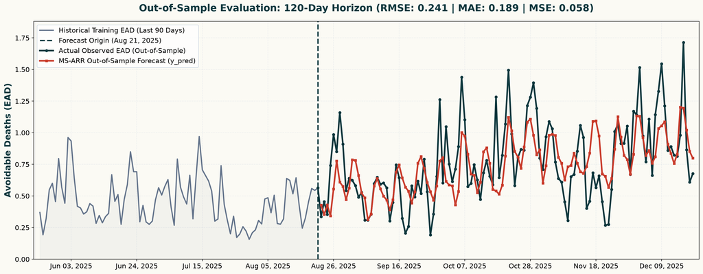

Generated Figure

> [!NOTE] Forecasts are recursively generated every 5 days, yielding 24 evaluation cycles across the 120-day horizon.

## 6. Beyond Point Forecasting: Uncertainty Quantification & Peak Signals

While point forecasts capture the conditional mean, operational decision-makers in emergency care require **probabilistic fan charts, distribution tails, and calibrated surge triggers**.

### Predictive Distribution Across Horizons ($h = 1 \dots 5$)

Ridgeline kernel density estimates (KDE) demonstrate how uncertainty widens across horizons, showing where the actual outcome landed relative to the conditional point forecast and the 95th percentile risk threshold:

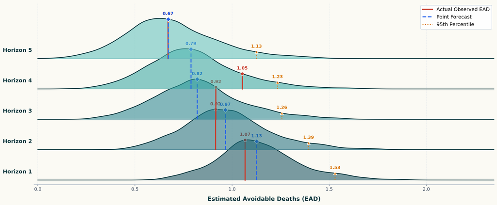

Generated Figure

### Can Calibrated Uncertainty Bounds Capture Peaks in EAD?

By constructing 80% and 90% predictive intervals, we can assess empirical coverage reliability over the 120-day holdout:

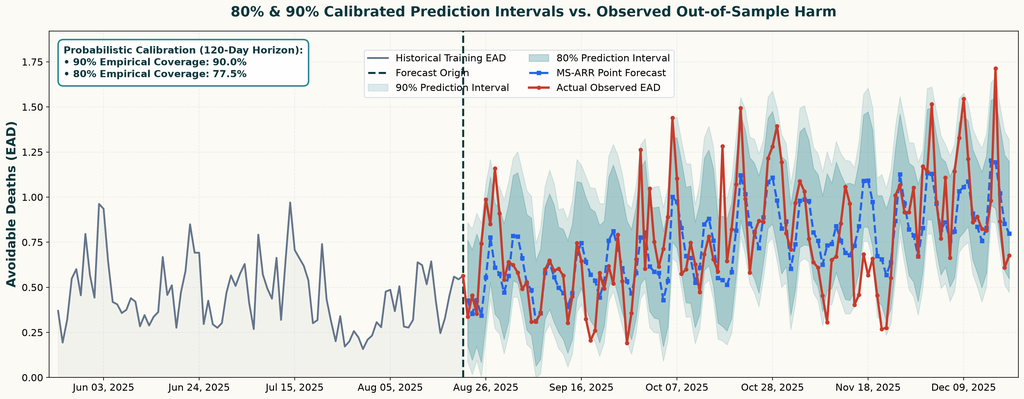

Generated Figure

## 7. Questions & Discussion 💬

[figure not shown]

[**Data Lab for Social Good** • Cardiff Business School • Cardiff University](https://mustafaslancoto.github.io/talks/presentations/sphere.html)